# Data analysis and statistics

rich-ramsey.github.io/talks/sbs-retreat-25/

Richard Ramsey  
[www.rich-ramsey.com](https://rich-ramsey.com)

## Aim

Provide the lab with a general context for thinking about data analysis and statistics.

[figure not shown]

[figure not shown]

**Warning**

I’m not a statistician. I’m not a statistician. I’m not a statistician…

## Overview

1. Background.
2. Caution.
3. Regression.
4. Summary.

[figure not shown]

[figure not shown]

# Background

## Sampling from a larger population

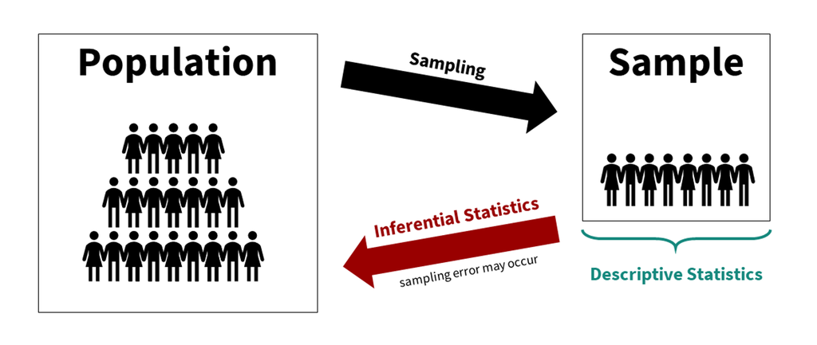

Image from: https://danawanzer.github.io/stats-with-jamovi/

## My background

- Cognitive neuroscience / experimental psychology.
- Social perception and cognition.
- I am not a statistician. (Did I say that already?)
- More recently: open science, methods and meta-science.

## My background

**My undergrad and postgrad stats classes looked like this:**

- Each week described a different statistical test.
- Your job was to choose the right test for a given type of data and run the test (usually via point-and-click in SPSS).
- Then you interpret the p-value.
- Job done.
- Easy, right?

## My background

**In the wake of the reproducibility crisis, I felt the need to become more statistically literate.**  
**Enter:**

- Richard McElreath’s excellent textbook (McElreath 2020)
- Solomon Kurz’s brilliant translation into `tidyverse` principles (Kurz 2023).
- Various papers and books by [Andrew Gelman](https://sites.stat.columbia.edu/gelman/).

# Caution

## Champagne inference on a beer budget

A quote from Andrew Gelman [(Gelman, 2024)](https://sites.stat.columbia.edu/gelman/research/published/jcp.pdf):

> once the data have been collected, the most important decisions have already been done

## Champagne inference on a beer budget

All statistical models are fundamentally limited and need to be framed within the wider scientific context (McElreath 2020), such as:

- The importance of theory
- Open data and materials
- Pre-registration
- Meta-analyses
- Computational modelling
- Data science
- Experimental design
- And many more besides

## Champagne inference on a beer budget

Before we make inferences and draw conclusions, we should spend more time (Scheel et al. 2021):

- Forming concepts.
- Developing valid measures.
- Identifying boundary conditions and auxillary assumptions.
- And so on…

## Champagne inference on a beer budget

**Measurement schmeasurement**

> We demonstrate that psychology is plagued by a measurement schmeasurement attitude: questionable measurement practices are common, hide a stunning source of researcher degrees of freedom, pose a serious threat to cumulative psychological science, but are largely ignored.

(Flake and Fried 2020)

## Caution (!) is required

- Statistical inference is not magical.
- Inferences rest on many assumptions and data quality.
- Inferences are likely to be fragile/tentative/suggestive.
- So, be cautious!
- And try to create research designs that do not rely too heavily on one particular part of your inferential model.

## Towards statistical *thinking*

- Develop a statistical philosophy rather than rely on historical statistical rituals (Gigerenzer 2018).
- There are many different approaches to the same question.
- Have a sense of how your approach fits into the mix of options, in terms of pros and cons.
- Be able to defend and justify your choices explicitly.

# Regression

## Single-level linear regression

$$\color{red}{Y_i} = \color{orange}{\beta_0} + \color{green}{\beta_1} \color{blue}{X_i} + \color{violet}{\varepsilon_i}$$

- $\color{red}{Y_i}$: The outcome/response variable for observation $i$
- $\color{orange}{\beta_0}$: The intercept (value of $Y$ when $X = 0$)
- $\color{green}{\beta_1}$: The slope (change in $Y$ for one unit increase in $X$)
- $\color{blue}{X_i}$: The predictor variable for observation $i$
- $\color{violet}{\varepsilon_i}$: The error term (residual) for observation $i$

## Common statistical tests are forms of linear regression

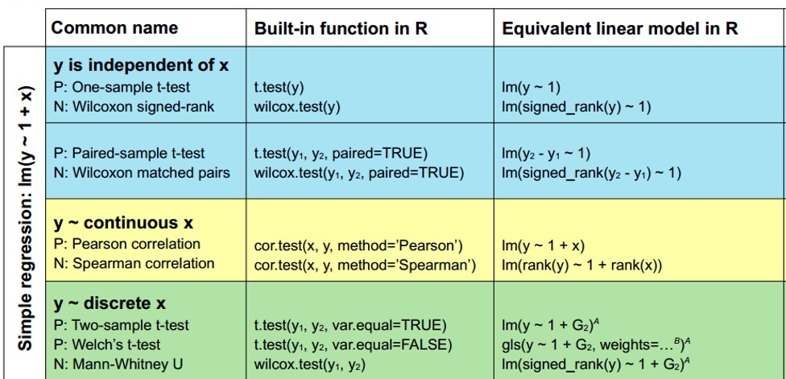

https://lindeloev.github.io/tests-as-linear/

## Homework

- Go away, get some data and run single level regressions in R.
- Use different types of data - continuous and categorical predictors etc.
- *I bet there are a million tutorials online.*
- **Aim:** understand the basics of single level regression - the rest builds on this core foundation.

[figure not shown]

## Multi-level linear regression

$$\color{red}{Y_{ij}} = (\color{orange}{\gamma_{00}} + \color{yellow}{u_{0j}}) + (\color{green}{\gamma_{10}} + \color{cyan}{u_{1j}})\color{blue}{X_{ij}} + \color{violet}{\varepsilon_{ij}}$$

- $\color{red}{Y_{ij}}$: The outcome variable for observation $i$ in group $j$
- $\color{orange}{\gamma_{00}}$: The fixed effect intercept (population average)
- $\color{yellow}{u_{0j}}$: The random/varying intercept for group $j$
- $\color{green}{\gamma_{10}}$: The fixed effect slope (population average)
- $\color{cyan}{u_{1j}}$: The random/varying slope for group $j$
- $\color{blue}{X_{ij}}$: The predictor variable for observation $i$ in group $j$
- $\color{violet}{\varepsilon_{ij}}$: The error term for observation $i$ in group $j$

## Multi-level regression: why bother?

- One general and versatile way to approach data analysis.
- It avoids picking the “right” statistical test.
- There is an active community of users and lots of resources.
- It is suitable for most data in psychology and human neuroscience, which typically has a nested (multi-level) structure e.g., sub-groups within a bigger group.
- It takes advantage of partial pooling / shrinkage.

## Summary vs trial-level data

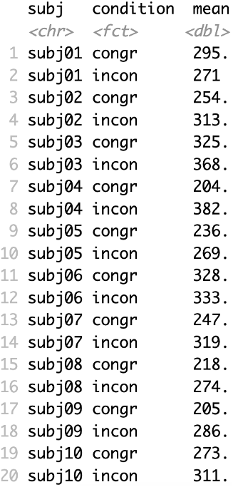

summary / aggregated data

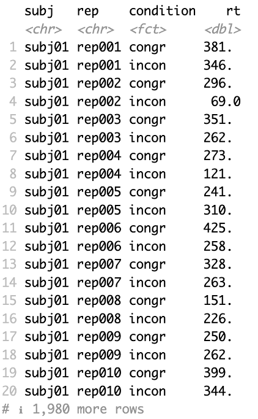

trial-level data

## Partial pooling or shrinkage

### let’s build in an intuition

[figure not shown]

[figure not shown]

## Partial pooling or shrinkage

### let’s plot it

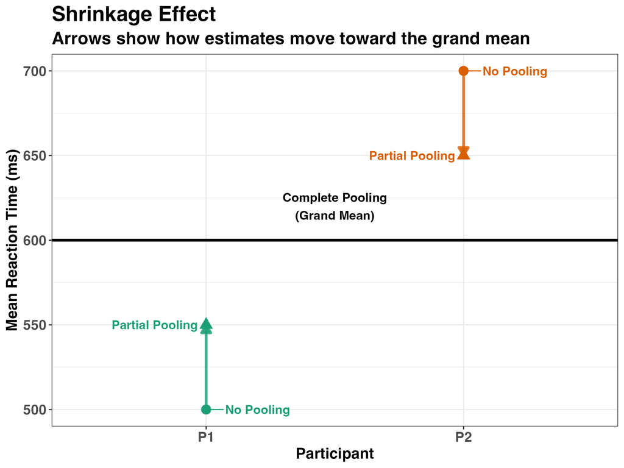

## Partial pooling or shrinkage

### let’s plot it

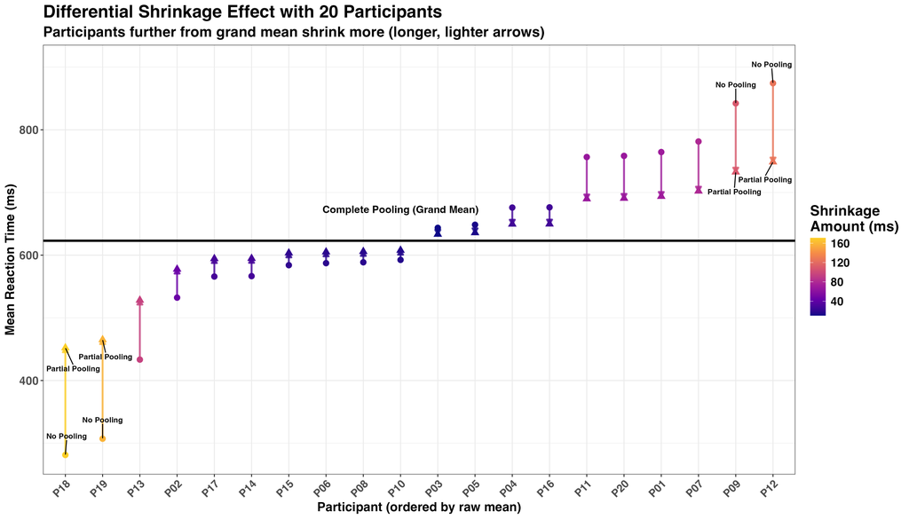

## Fixed and varying effects

```r
# specify the model formula with only fixed or population-level terms
formula = dv ~ 1 + condition


# and now add varying intercepts per participant
formula = dv ~ 1 + condition +
  (1 | participant)


# and now add varying intercepts and slopes per participant
formula = dv ~ 1 + condition +
  (1 + condition | participant)
```

## Estimation approaches - basics

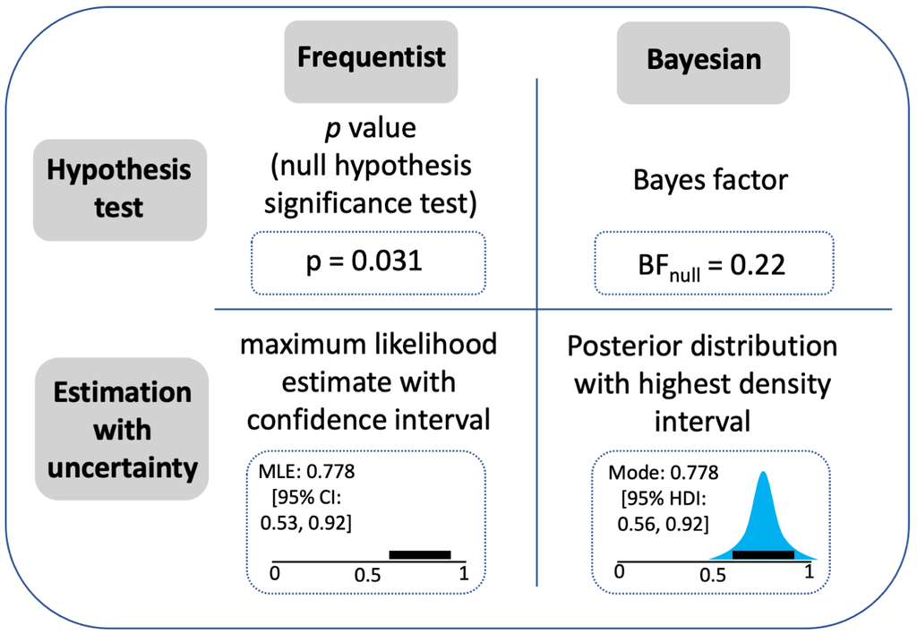

Adapted from Kruschke and Liddell (2018)

## Estimation approaches - parameters

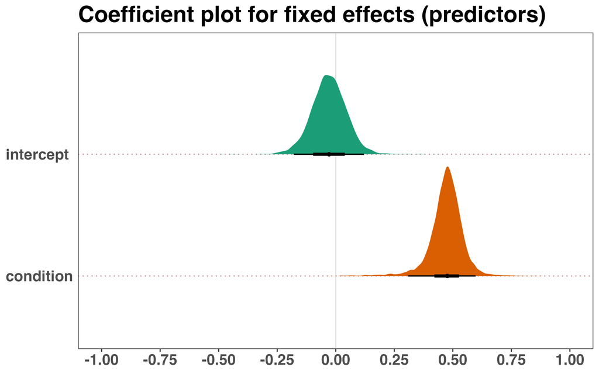

## Estimation approaches - parameters

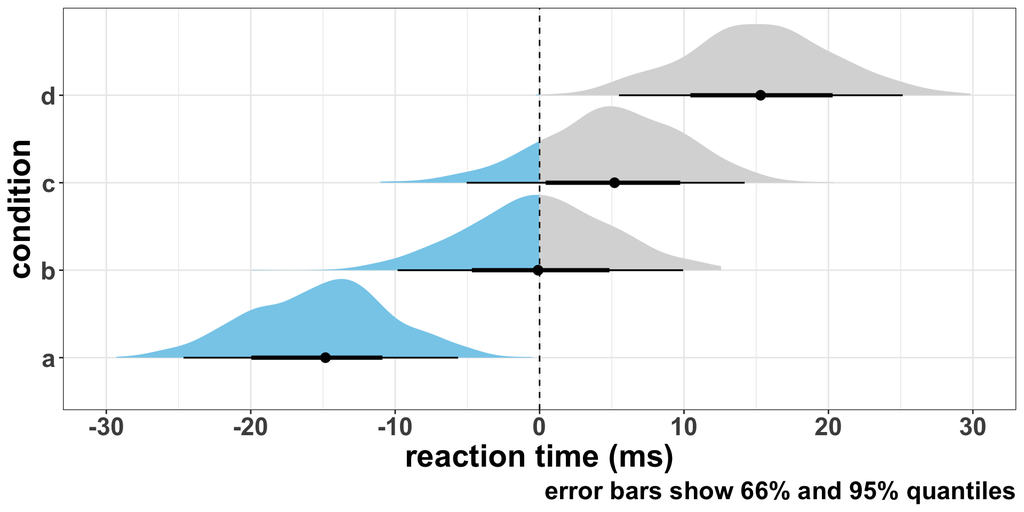

[Adapted from: https://mjskay.github.io/tidybayes/]

## Estimation approaches - wider reading

[figure not shown]

[figure not shown]

[figure not shown]

# Summary

## Science needs more David Bowie

- Statistical reform is important.
- But science is not a one-trick pony.
- We need more David Bowie.

[figure not shown]

https://vocal.media/beat/reinventing-david-bowie

## Thanks for your attention

**And thanks to these fine folks:**

- John Bartlett for his [tutorial](https://bartlettje.github.io/dissemination_quarto/quarto_presentations.html#creating-a-quarto-presentation) on reproducible presentations in R (*this is solid gold*).
- Lisa Debruine for sharing lots of [example presentations](https://github.com/debruine/talks/tree/master)

**Resources:**

- Unless otherwise specified, icons were used under license from [The Noun Project](https://thenounproject.com/)
- Slides were created with [Quarto](https://quarto.org/) and [RevealJS](https://revealjs.com/)

## And here’s my stuff

- Slides: www.rich-ramsey.github.io/talks/sbs-retreat-25/
- Code: https://github.com/rich-ramsey/talks
- Website: www.rich-ramsey.com
- Github: https://github.com/rich-ramsey

## References

Flake, Jessica Kay, and Eiko I. Fried. 2020. “Measurement Schmeasurement: Questionable Measurement Practices and How to Avoid Them.” *Advances in Methods and Practices in Psychological Science* 3: 456–65. https://doi.org/10.1177/2515245920952393.

Gigerenzer, Gerd. 2018. “Statistical Rituals: The Replication Delusion and How We Got There.” *Advances in Methods and Practices in Psychological Science* 1 (2): 198–218. https://doi.org/10.1177/2515245918771329.

Kruschke, J. K., and T. M. Liddell. 2018. “The Bayesian New Statistics: Hypothesis Testing, Estimation, Meta-Analysis, and Power Analysis from a Bayesian Perspective.” *Psychon Bull Rev* 25 (1): 178–206. https://doi.org/10.3758/s13423-016-1221-4.

Kruschke, John. 2014. *Doing Bayesian Data Analysis: A Tutorial with R, JAGS, and Stan*. Academic Press. https://books.google.com?id=FzvLAwAAQBAJ.

Kurz, A. Solomon. 2023. *Statistical Rethinking with Brms, Ggplot2, and the Tidyverse: Second Edition*. Version 0.4.0. https://bookdown.org/content/4857/.

McElreath, Richard. 2020. *Statistical Rethinking: A Bayesian Course with Examples in R and Stan*. CRC press.

Scheel, Anne M., Leonid Tiokhin, Peder M. Isager, and Daniël Lakens. 2021. “Why Hypothesis Testers Should Spend Less Time Testing Hypotheses.” *Perspectives on Psychological Science* 16: 744–55. https://doi.org/10.1177/1745691620966795.

Winter, Bodo. 2019. *Statistics for Linguists: An Introduction Using R*. Routledge. https://books.google.com?id=8cbADwAAQBAJ.

[figure not shown]